# Ayudantía 3

Econometría I

Juan Felipe Ly

02/09/2021

# ¿Discriminan los precios de las cadenas de comida rápida en función de la raza y las características de ingresos de un área?

1. ¿Cuántas variables y observaciones contiene la base de datos?
2. Muestre las primeras 10 observaciones.

| psoda | pfries | pentree | wagest | nmgrs | nregs | hrsopen | emp | psoda2 | pfries2 | pentree2 | wagest2 | nmgrs2 | nregs2 | hrsopen2 | emp2 | compown | chain | density | crmrte | state | prpblck | prppov | prpncar | hseval | nstores | income | county | lpsoda | lpfries | … |
| --- | --- | --- | --- | --- | --- | --- | --- | --- | --- | --- | --- | --- | --- | --- | --- | --- | --- | --- | --- | --- | --- | --- | --- | --- | --- | --- | --- | --- | --- | --- |
| 1.12 | 1.06 | 1.02 | 4.25 | 3 | 5 | 16.0 | 27.5 | 1.11 | 1.11 | 1.05 | 5.05 | 5 | 5 | 15.0 | 27.0 | 1 | 3 | 4030 | 0.0528866 | 1 | 0.1711542 | 0.0365789 | 0.0788428 | 148300 | 3 | 44534 | 18 | 0.11332869 | 0.05826885 | … |
| 1.06 | 0.91 | 0.95 | 4.75 | 3 | 3 | 16.5 | 21.5 | 1.05 | 0.89 | 0.95 | 5.05 | 4 | 3 | 17.5 | 24.5 | 0 | 1 | 4030 | 0.0528866 | 1 | 0.1711542 | 0.0365789 | 0.0788428 | 148300 | 3 | 44534 | 18 | 0.05826885 | -0.09431065 | … |
| 1.06 | 0.91 | 0.98 | 4.25 | 3 | 5 | 18.0 | 30.0 | 1.05 | 0.94 | 0.98 | 5.05 | 4 | 5 | 17.5 | 25.0 | 0 | 1 | 11400 | 0.0360003 | 1 | 0.0473602 | 0.0879072 | 0.2694298 | 169200 | 3 | 41164 | 12 | 0.05826885 | -0.09431065 | … |
| 1.06 | 0.95 | 1.01 | 4.25 | 4 | 4 | 15.0 | 17.5 | 1.05 | 0.94 | 1.00 | 5.05 | 3 | 4 | 15.0 | 28.0 | 0 | 1 | 4424 | 0.0334823 | 1 | 0.0591327 | 0.0835001 | 0.1151341 | 148000 | 2 | 44515 | 18 | 0.05826885 | -0.05129331 | … |
| 1.17 | 0.95 | 0.95 | 4.65 | 3 | 2 | 16.0 | 22.5 | 1.05 | 0.94 | 0.94 | 5.05 | 3 | 2 | 16.0 | 18.5 | 0 | 1 | 2678 | 0.0310296 | 1 | 0.0186773 | 0.0292349 | 0.0501854 | 212700 | 1 | 62056 | 10 | 0.15700372 | -0.05129331 | … |
| 1.17 | 1.02 | 1.06 | 4.50 | 3 | 5 | 17.0 | 18.5 | 1.11 | 1.06 | 1.05 | 5.05 | 3 | 5 | 16.0 | 17.0 | 1 | 3 | 6405 | 0.0419001 | 1 | 0.0049060 | 0.0337599 | 0.0827105 | 198800 | 1 | 53655 | 24 | 0.15700372 | 0.01980261 | … |
| 1.17 | 1.12 | 1.02 | 4.25 | 3 | 5 | 18.0 | 27.0 | 1.11 | 1.12 | 1.05 | 5.05 | 6 | 5 | 17.0 | 22.0 | 1 | 3 | 18388 | 0.0945454 | 1 | 0.9210559 | 0.2036816 | 0.3919490 | 103800 | 5 | 31314 | 10 | 0.15700372 | 0.11332869 | … |
| 1.06 | 1.02 | 2.34 | 4.75 | 3 | 5 | 12.0 | 11.0 | 1.05 | 1.05 | 2.32 | 5.05 | 5 | 5 | 12.0 | 32.5 | 1 | 2 | 18388 | 0.0945454 | 1 | 0.9210559 | 0.2036816 | 0.3919490 | 103800 | 5 | 31314 | 10 | 0.05826885 | 0.01980261 | … |
| 1.06 | 1.05 | 1.06 | 4.50 | 4 | 2 | 15.5 | 20.0 | 1.11 | 1.09 | 2.07 | 5.05 | 4 | 2 | 15.5 | 20.0 | 0 | 4 | 18388 | 0.0945454 | 1 | 0.9210559 | 0.2036816 | 0.3919490 | 103800 | 5 | 31314 | 10 | 0.05826885 | 0.04879012 | … |
| 1.05 | 0.95 | 2.74 | 4.25 | 3 | 5 | 13.5 | 17.0 | 1.05 | 0.84 | 2.32 | 5.05 | 2 | 5 | 12.5 | 9.5 | 0 | 2 | 11401 | 0.1482300 | 1 | 0.9210559 | 0.2036816 | 0.3919490 | 103800 | 5 | 31314 | 10 | 0.04879012 | -0.05129331 | … |

3. Determine los valores promedio, en la muestra, de `prpblck` (proporción de población afroamericana) y de `income` (ingreso familiar promedio), junto con sus desviaciones estándar. ¿Cuáles son las unidades de `prpblck` e `income`?

| Variables | Media | Desv. Estándar | Mínimo | p25 | p50 | p75 | Máximo |
| --- | --- | --- | --- | --- | --- | --- | --- |
| psoda | 1.0 | 0.1 | 0.7 | 1.0 | 1.1 | 1.1 | 1.5 |
| income | 46833.4 | 13686.9 | 15919.0 | 37394.5 | 45907.0 | 54243.0 | 136529.0 |
| prpblck | 0.1 | 0.2 | 0.0 | 0.0 | 0.0 | 0.1 | 1.0 |

4. Muestre la relación entre las variables `psoda`, `prpblck` e `income`, usando una matriz de dispersión.

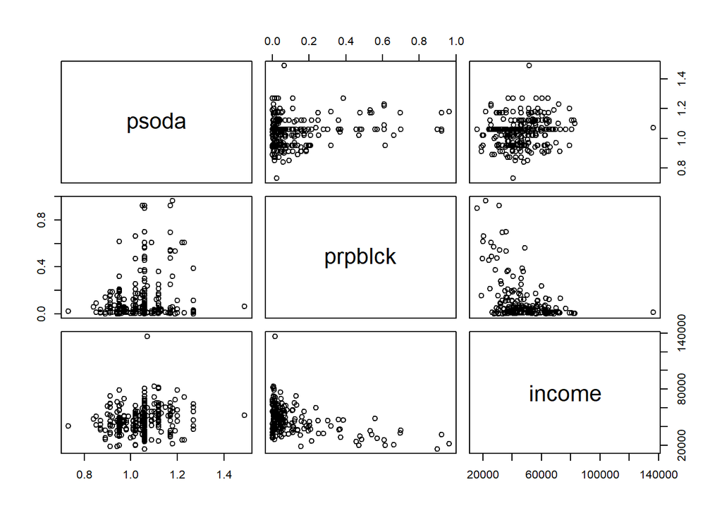

5. Considere un modelo para explicar el precio de las bebidas refrescantes, `psoda`, en términos de la proporción de población afroamericana y de ingreso promedio:

$$psoda = \beta_0 + \beta_1 \cdot (prpblck) + \beta_2 \cdot (income) + u$$

Estime este modelo mediante MCO y muestre un resumen con los resultados de la estimación obtenidos.

|  | *Dependent variable:* |
| --- | --- |
|  | psoda |
| prpblck | 0.148095*** |
|  | (0.030027) |
| income | 0.000002*** |
|  | (0.0000004) |
| Constant | 0.941154*** |
|  | (0.021429) |
| Observations | 310 |
| R<sup>2</sup> | 0.091409 |
| Adjusted R<sup>2</sup> | 0.085490 |
| Residual Std. Error | 0.085710 (df = 307) |
| F Statistic | 15.442910*** (df = 2; 307) |
| *Note:* | p<0.1; p<0.05; p<0.01 |

6. Interprete el intercepto.

**R**: En el caso de zonas que no tienen población afroamericana (`prpblck`=0) y la variable `income` toma valor 0 para esa observación, entonces el precio promedio de una soda mediana es de 0.9411 dólares.

7. Interprete el coeficiente de prpblck y el de income.

**R**: Digamos que, manteniendo las demás variables constantes, si `prpblack` aumenta en 0.10 (10 puntos porcentuales), el precio de la soda mediana se estima que aumente en 0.0148 dólares, o casi 1.5 centavos. En el caso de `income`, si la mediana de ingreso de una familia aumenta en 1 dólar, manteniendo el resto de las variables constantes, entonces el precio promedio de la soda mediana se estima que aumente en en 0.000002 dólares.

8. Interprete el R-squared obtenido en (e).

**R:** El R-squared obtenido indica que las variables `prpblck` e `income`, en conjunto, explican un 9.1% de la variabilidad de la variable regresada, psoda.

$$psoda = \beta_0 + \beta_1 \cdot (prpblck) + \beta_2 \cdot (income) + u$$

1. Calcule un intervalo de confianza para $\beta_1$ utilizando un nivel de confianza del 95%.

|  | 2.5 % | 97.5 % |
| --- | --- | --- |
| prpblck | 0.089011 | 0.207179 |

10. Calcule los precios de las sodas predichos por el modelo y los residuos. Muestre las primeras 10 observaciones de las variables `psoda`, psoda estimado y los residuos estimados por el modelo.

| psoda | Predpsoda | Residuo |
| --- | --- | --- |
| 1.12 | 1.049536 | 0.070464 |
| 1.06 | 1.049536 | 0.010464 |
| 1.06 | 1.024919 | 0.035080 |
| 1.06 | 1.032911 | 0.027089 |
| 1.17 | 1.059626 | 0.110374 |
| 1.17 | 1.041922 | 0.128078 |
| 1.17 | 1.135944 | 0.034056 |
| 1.06 | 1.135944 | -0.075944 |
| 1.06 | 1.135944 | -0.075944 |
| 1.05 | 1.135944 | -0.085944 |